# Table of Contents

## Imports

```python
import pandas as pd
import matplotlib.pyplot as plt
import seaborn as sns
import statsmodels.formula.api as smf
import statsmodels.api as sm
import scipy.stats as stats
import numpy as np
```

```python
# define ANOVA function to calculate adjusted effect sizes
def anova_table(aov):
    aov['mean_sq'] = aov[:]['sum_sq']/aov[:]['df']
    aov['eta_sq'] = aov[:-1]['sum_sq']/sum(aov['sum_sq'])
    aov['omega_sq'] = (aov[:-1]['sum_sq']-(aov[:-1]['df']*aov['mean_sq'][-1]))/(sum(aov['sum_sq'])+aov['mean_sq'][-1])
    cols = ['sum_sq', 'df', 'mean_sq', 'F', 'PR(>F)', 'eta_sq', 'omega_sq']
    aov = aov[cols]
    return aov
```

## Loading the data

```python
# load the raw cortisol data
cort_data = pd.read_excel('cortisol_data.xlsx')
cort_data.head()
```

|  | Subject Number | Sample | Cortisol (ug/dL) | Cortisol (nmol/L) | Notes |
| --- | --- | --- | --- | --- | --- |
| 0 | 2707 | D1S1 | 0.182 | 5.02138 | NaN |
| 1 | 2707 | D1S2 | 0.550 | 15.17450 | NaN |
| 2 | 2707 | D1S3 | 0.552 | 15.22968 | NaN |
| 3 | 2707 | D1S4 | 0.444 | 12.24996 | NaN |
| 4 | 2707 | D1S5 | 0.088 | 2.42792 | NaN |

```python
# load the study data
df = pd.read_excel('data.xlsx')
```

## Wrangling the data into shape

As seen above, the raw cortisol data is output from an ELISA plate reader, so is long form, with each row representing a single cortisol sample. This needs to be converted into wide data so it can be merged into the existing study database (by subject).

```python
wide_data = cort_data.pivot(index='Subject Number', columns='Sample', values='Cortisol (nmol/L)')
wide_data.head()
```

| Sample Subject Number | D1S1 | D1S2 | D1S3 | D1S4 | D1S5 | D1S6 | D2S1 | D2S2 | D2S3 | D2S4 | D2S5 | cTBS |
| --- | --- | --- | --- | --- | --- | --- | --- | --- | --- | --- | --- | --- |
| 1411 | 3.94537 | 3.50393 | 3.39357 | 2.81418 | 0.55180 | 0.33100 | 7.55966 | 11.53262 | 11.14636 | 7.53207 | 0.82770 | 3.44875 |
| 1833 | 3.58670 | 9.90481 | 14.70547 | 13.71223 | 1.82094 | 0.96565 | 2.70382 | 8.63567 | 14.01572 | 15.56076 | 1.60022 | 1.54504 |
| 2045 | 1.60022 | 0.88288 | 7.09063 | 8.35977 | 6.12498 | 2.04166 | 6.12498 | 6.84232 | 7.83556 | 7.20099 | NaN | 3.11767 |
| 2060 | NaN | 5.07656 | 7.69761 | 6.48365 | 0.85529 | 0.33100 | 4.60753 | 4.27645 | 3.44875 | NaN | 0.46903 | 1.04842 |
| 2152 | 21.87887 | 11.36708 | 7.06304 | 4.41440 | 2.97972 | 0.88288 | 8.24941 | 2.42792 | 14.04331 | 15.17450 | 2.78659 | 2.97972 |

```python
# assigning cTBS values to D2S5 where appropriate (these samples are equivalent in some subjects)
wide_data['D2S5'] = np.where(wide_data['D2S5'].isna(), wide_data['cTBS'], wide_data['D2S5'])
```

That's better. Before merging the data, first we will impute some missing data. This is a small sample, so dropping subjects with missing samples is not possible.

```python
# imputing missing data
from sklearn.impute import SimpleImputer
imputer = SimpleImputer(strategy = 'median')
imputer = imputer.fit(wide_data.iloc[:, 0:10])
wide_data.iloc[:, 0:10] = imputer.transform(wide_data.iloc[:, 0:10])
```

## Merging datasets

```python
df = pd.merge(df, wide_data, left_on='study_no', right_on='Subject Number')
df.head()
```

|  | study_no | Gest_age_del | age_s2 | RMTS2 | AMTpa | AMTap | AMTlm | AMTap_pa_prop | SI1mVS2 | RMTcTBS_S2 | ... | D1S3 | D1S4 | D1S5 | D1S6 | D2S1 | D2S2 | D2S3 | D2S4 | D2S5 | cTBS |
| --- | --- | --- | --- | --- | --- | --- | --- | --- | --- | --- | --- | --- | --- | --- | --- | --- | --- | --- | --- | --- | --- |
| 0 | 1411 | 274.0 | 13.583333 | 40.0 | 34.0 | 48.0 | 37.0 | 1.411765 | 61.0 | 53.0 | ... | 3.39357 | 2.81418 | 0.55180 | 0.33100 | 7.55966 | 11.53262 | 11.14636 | 7.532070 | 0.82770 | 3.44875 |
| 1 | 1833 | 265.0 | 12.083333 | 48.0 | 35.0 | 53.0 | 46.0 | 1.514286 | 81.0 | 65.0 | ... | 14.70547 | 13.71223 | 1.82094 | 0.96565 | 2.70382 | 8.63567 | 14.01572 | 15.560760 | 1.60022 | 1.54504 |
| 2 | 2045 | 287.0 | 13.833333 | 47.0 | 38.0 | 44.0 | 39.0 | 1.157895 | 53.0 | 55.0 | ... | 7.09063 | 8.35977 | 6.12498 | 2.04166 | 6.12498 | 6.84232 | 7.83556 | 7.200990 | 3.11767 | 3.11767 |
| 3 | 2060 | 278.0 | 12.750000 | 46.0 | 35.0 | 42.0 | 40.0 | 1.200000 | 56.0 | 55.0 | ... | 7.69761 | 6.48365 | 0.85529 | 0.33100 | 4.60753 | 4.27645 | 3.44875 | 8.097665 | 0.46903 | 1.04842 |
| 4 | 2152 | 278.0 | 14.083333 | 50.0 | 43.0 | 60.0 | 52.0 | 1.395349 | 63.0 | 68.0 | ... | 7.06304 | 4.41440 | 2.97972 | 0.88288 | 8.24941 | 2.42792 | 14.04331 | 15.174500 | 2.78659 | 2.97972 |

5 rows × 104 columns

Now each subject in the study database has their cortisol samples as columns.

## Dealing with time data

Now we need to create some variables. Some of the data represents time, but is stored as int (e.g. 930 for 09:30 am). We'll convert these to datetime and then calculate some variables we'll need later in analysis.

### Sampling duration

```python
# calculating the duration of each subject's day (first to last sample)
for t in range(1,7):
    df['D1T{}dt'.format(t)] = pd.to_datetime(df['D1T{}'.format(t)], format='%H%M')
```

```python
df['duration'] = (df['D1T6dt'] - df['D1T1dt'])
```

```python
df['duration_hours'] = df.apply(lambda x: (x['D1T6dt']-x['D1T1dt']).seconds/60/60, axis=1)
```

### Sampling latency

```python
# calculating the time taken between awakening and first sample
var_list = ['WakeTimeD1','WakeTimeD2','D1T1','D2T1']
for var in var_list:
    df[var+'dt'] = pd.to_datetime(df[var], format='%H%M')

df['sample_latencyD1'] = df['D1T1dt'] - df['WakeTimeD1dt']
df['sample_latencyD1_mins'] = df.apply(lambda x: x['sample_latencyD1'].seconds/60, axis=1)

df['sample_latencyD2'] = df['D2T1dt'] - df['WakeTimeD2dt']
df['sample_latencyD2_mins'] = df.apply(lambda x: x['sample_latencyD2'].seconds/60, axis=1)

df['sample_latency_mean_mins'] = (df['sample_latencyD1_mins'] + df['sample_latencyD2_mins'])/2
```

### Inter-sample intervals

```python
# time taken between each sample
times = ['D1T1dt','D1T2dt','D1T3dt','D1T4dt','D1T5dt','D1T6dt']

for i in range(1,6):
    df['interval{}'.format(i)] = df.apply(lambda x: (x[times[i]]-x[times[i-1]]).seconds/60, axis=1)
```

## Calculating AUC

Perhaps the most important step in this analysis is calculating the area under the curve (AUC) of the cortisol awakening response, as this is the primary index of the CAR. There are two types: AUC with respect to ground (AUCg) and AUC with respect to increase (AUCi). The former represents total hormonal output, while the latter reflects responsitivity, or rate of change over the samples. We'll calculate each of these for each day and then take the mean.

```python
# AUC formulas
aucg_d1_formula = lambda x: (((x.D1S2 + x.D1S1)*15)/2) + (((x.D1S3 + x.D1S2)*15)/2) + (((x.D1S4 + x.D1S3)*15)/2)
auci_d1_formula = lambda x: ((((x.D1S2 + x.D1S1)*15)/2) + (((x.D1S3 + x.D1S2)*15)/2) + (((x.D1S4 + x.D1S3)*15)/2)) - x.D1S1*(15*4)

aucg_d2_formula = lambda x: ((((x.D2S2 + x.D2S1)*15)/2) + (((x.D2S3 + x.D2S2)*15)/2) + (((x.D2S4 + x.D2S3)*15)/2))
auci_d2_formula = lambda x: ((((x.D2S2 + x.D2S1)*15)/2) + (((x.D2S3 + x.D2S2)*15)/2) + (((x.D2S4 + x.D2S3)*15)/2)) - x.D2S1*(15*4)
```

```python
# Computing AUCs
# Day 1
df['AUCgD1'] = df.apply(aucg_d1_formula, axis=1)
df['AUCiD1'] = df.apply(auci_d1_formula, axis=1)
# Day 2
df['AUCgD2'] = df.apply(aucg_d2_formula, axis=1)
df['AUCiD2'] = df.apply(auci_d2_formula, axis=1)
# Mean
df['AUCimean'] = (df['AUCiD1'] + df['AUCiD2'])/2
df['AUCgmean'] = (df['AUCgD1'] + df['AUCgD2'])/2
```

## Calculating the diurnal slope

```python
subjects = list(df['study_no'].unique())
values = {'D1S1':0, 'D1S2':15, 'D1S3':30, 'D1S4':45, 'D1S5':60, 'D1S6':75}
cort_data_slope = cort_data
cort_data_slope['Sample'].replace(values, inplace=True)
# selecting data from day 1
cort_data_slope = cort_data_slope[cort_data_slope['Sample'].isin([0,15,30,45,60,75])]

# slope function - plots a regression line through each subjects morning, afternoon, and night samples
def slope(subject):
    data = cort_data_slope[cort_data_slope['Subject Number']==subject]
    data = data[~data['Sample'].isin([15,30,45])]
    X = data['Sample']
    X = sm.add_constant(X.values)
    y = data['Cortisol (nmol/L)']
    reg = sm.OLS(y.astype(float), X.astype(float)).fit()
    b = reg.params[1]
    return b
```

```python
# compute slopes and add to the dataframe
df['diurnal_slope'] = np.nan

for subject in subjects:
    b = slope(subject)
    df.loc[df['study_no']==subject, 'diurnal_slope'] = b
```

```python
# now that the data is ready, we split into groups to aid in later comparisons
gdm = df[df['GDM']==1]
control = df[df['GDM']==0]
```

## Converting back to long

We'll need a long dataset to easily plot the CAR later.

```python
d1_long = pd.melt(id_vars=['study_no','GDM'], value_vars=df.loc[:,'D1S1':'D1S6'], var_name='sample', value_name='cortisol', frame=df)
d1_long['day'] = 1

d2_long = pd.melt(id_vars=['study_no','GDM'], value_vars=df.loc[:,'D2S1':'cTBS'], var_name='sample', value_name='cortisol', frame=df)
d2_long['day'] = 2
```

```python
# changing the sample names for easier plotting
sample_names_d1 = {'D1S1':0, 'D1S2':15, 'D1S3':30, 'D1S4':45, 'D1S5':60, 'D1S6':75}
sample_names_d2 = {'D2S1':0, 'D2S2':15, 'D2S3':30, 'D2S4':45, 'D2S5':60, 'cTBS':75}

d1_long = d1_long.replace({'sample':sample_names_d1})
d2_long = d2_long.replace({'sample':sample_names_d2})
```

```python
# concatenate into one dataframe
df_long = pd.concat([d1_long, d2_long])
```

## Statistics

Now that's done, we can start analysing the data!

### Descriptives

```python
round(df[['AUCimean','AUCgmean','auc_diurnal_d1','diurnal_slope']].describe(), 2)
```

|  | AUCimean | AUCgmean | auc_diurnal_d1 | diurnal_slope |
| --- | --- | --- | --- | --- |
| count | 32.00 | 32.00 | 31.00 | 27.00 |
| mean | 8.87 | 416.70 | 4667.15 | -0.08 |
| std | 159.66 | 158.25 | 1866.87 | 0.07 |
| min | -455.65 | 122.91 | 957.69 | -0.29 |
| 25% | -74.86 | 307.57 | 2968.29 | -0.11 |
| 50% | -2.28 | 447.48 | 4721.62 | -0.05 |
| 75% | 101.37 | 518.50 | 6114.94 | -0.03 |
| max | 318.46 | 763.45 | 8072.60 | 0.03 |

### Normality tests

We'll be running linear models and ANOVAs, so first we'll check that our data is normally distributed.

```python
print(stats.shapiro(df['AUCimean']))
print(stats.shapiro(df['AUCgmean']))
```

```
(0.9635738134384155, 0.34294548630714417)
(0.9709528684616089, 0.5261117219924927)
```

```python
print(stats.shapiro(gdm['AUCimean']))
print(stats.shapiro(gdm['AUCgmean']))
```

```
(0.9537766575813293, 0.37444818019866943)
(0.9686221480369568, 0.6791777014732361)
```

```python
print(stats.shapiro(control['AUCimean']))
print(stats.shapiro(control['AUCgmean']))
```

```
(0.9695404767990112, 0.8865522146224976)
(0.9240884184837341, 0.3923186957836151)
```

### Difference in AUCs

```python
model = smf.ols('AUCgmean ~ C(GDM)', data=df).fit()
#print(model.summary())
aov_table = sm.stats.anova_lm(model, typ=2)
print(anova_table(aov_table))
print(df.groupby('GDM')['AUCgmean'].agg(['mean','std']))
print('Normality:   ', stats.shapiro(model.resid))
print(stats.levene(gdm['AUCgmean'], control['AUCgmean']))
```

```
                 sum_sq    df        mean_sq         F    PR(>F)    eta_sq  \
C(GDM)    120904.429150   1.0  120904.429150  5.533686  0.025409  0.155731
Residual  655464.185743  30.0   21848.806191       NaN       NaN       NaN

          omega_sq
C(GDM)    0.124096
Residual       NaN
           mean         std
GDM
0    507.866374  127.002616
1    375.253785  155.884146
Normality:    (0.9776697754859924, 0.7295458912849426)
LeveneResult(statistic=1.150873739559068, pvalue=0.29192041912223843)
```

```python
model = smf.ols('AUCimean ~ C(GDM)', data=df).fit()
#print(model.summary())
aov_table = sm.stats.anova_lm(model, typ=2)
print(anova_table(aov_table))
print(df.groupby('GDM')['AUCimean'].agg(['mean','std']))
print('Normality:   ', stats.shapiro(model.resid))
print(stats.levene(gdm['AUCimean'], control['AUCimean']))
```

```
                 sum_sq    df       mean_sq         F    PR(>F)    eta_sq  \
C(GDM)      5103.760568   1.0   5103.760568  0.195026  0.661933  0.006459
Residual  785091.007695  30.0  26169.700256       NaN       NaN       NaN

          omega_sq
C(GDM)   -0.025805
Residual       NaN
          mean         std
GDM
0    -9.859976  101.642931
1    17.386403  181.542261
Normality:    (0.9619717001914978, 0.3107261657714844)
LeveneResult(statistic=2.686413664192418, pvalue=0.11165406436510628)
```

```python
model = smf.ols('aucg_diurnal_d1 ~ C(GDM) + duration_hours + interval4', data=df).fit()
#print(model.summary())
aov_table = sm.stats.anova_lm(model, typ=2)
print(anova_table(aov_table))
print(df.groupby('GDM')['auc_diurnal_d1'].agg(['mean','std']))
```

```
                      sum_sq    df       mean_sq         F    PR(>F)  \
C(GDM)          3.675610e+06   1.0  3.675610e+06  4.943904  0.034742
duration_hours  1.900929e+04   1.0  1.900929e+04  0.025569  0.874149
interval4       5.664103e+06   1.0  5.664103e+06  7.618540  0.010253
Residual        2.007350e+07  27.0  7.434630e+05       NaN       NaN

                  eta_sq  omega_sq
C(GDM)          0.124884  0.097169
duration_hours  0.000646 -0.024008
interval4       0.192446  0.163066
Residual             NaN       NaN
            mean          std
GDM
0    5665.100191  1626.178084
1    4258.899540  1835.759955
```

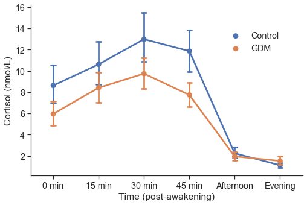

```python
#fig, ax = plt.subplots(figsize=(4, 4), dpi=300)
sns.set(style='ticks', font_scale=1.3) #rc={'figure.figsize':(4,4)},

g = sns.catplot(data=df_long, x='sample', y='cortisol', hue='GDM', kind='point',
                capsize=0.1, legend=True, aspect=1.3, ci=95)

g.set_xticklabels(labels=['0 min','15 min','30 min','45 min','Afternoon','Evening'])
g.set_xlabels('Time (post-awakening)')
g.set_ylabels('Cortisol (nmol/L)')
#plt.legend(title='Group', loc='upper right', labels=['Control', 'GDM'])
g._legend.texts[0].set_text("Control")
g._legend.texts[1].set_text("GDM")
g._legend.set_title("")
g._legend.set_bbox_to_anchor((0.9, 0.75))

plt.tight_layout()
```

### Difference in diurnal slopes

```python
model = smf.ols('diurnal_slope ~ C(GDM)', data=df).fit()
#print(model.summary())
aov_table = sm.stats.anova_lm(model, typ=2)
print(anova_table(aov_table))
print(df.groupby('GDM')['diurnal_slope'].agg(['mean','std']))
print('Normality:   ', stats.shapiro(model.resid))
```

```
            sum_sq    df   mean_sq         F    PR(>F)    eta_sq  omega_sq
C(GDM)    0.004985   1.0  0.004985  1.133969  0.297108  0.043391  0.004937
Residual  0.109895  25.0  0.004396       NaN       NaN       NaN       NaN
         mean       std
GDM
0   -0.102127  0.031100
1   -0.069444  0.072477
Normality:    (0.8813735246658325, 0.00514401588588953)
```

```python
model = smf.ols('diurnal_slope ~ C(GDM) + duration_hours', data=df).fit()
#print(model.summary())
aov_table = sm.stats.anova_lm(model, typ=2)
print(anova_table(aov_table))
```

```
                  sum_sq    df   mean_sq         F    PR(>F)    eta_sq  \
C(GDM)          0.005733   1.0  0.005733  1.333511  0.259550  0.049578
duration_hours  0.006722   1.0  0.006722  1.563584  0.223196  0.058132
Residual        0.103174  24.0  0.004299       NaN       NaN       NaN

                omega_sq
C(GDM)          0.011955
duration_hours  0.020202
Residual             NaN
```

```python
model = smf.ols('diurnal_slope ~ S1mean', data=df).fit()
#print(model.summary())
aov_table = sm.stats.anova_lm(model, typ=2)
print(anova_table(aov_table))
```

```
            sum_sq    df   mean_sq          F        PR(>F)   eta_sq  omega_sq
S1mean    0.080678   1.0  0.080678  58.971586  4.913379e-08  0.70228  0.682247
Residual  0.034202  25.0  0.001368        NaN           NaN      NaN       NaN
```

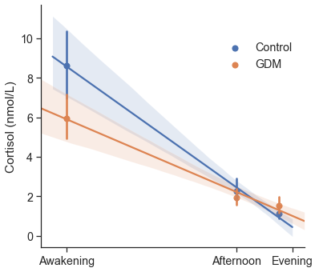

```python
sns.set(style='ticks', font_scale=1.3) #rc={'figure.figsize':(4,4)},

diurnal_long = df_long[~df_long['sample'].isin([15,30,45])]

g = sns.lmplot(x='sample', y='cortisol', data=diurnal_long, hue='GDM', x_estimator=np.mean, legend=True, aspect=1, ci=95)
ax = g.axes[0,0]

g.set_xticklabels(labels=['','Awakening','','','Afternoon','Evening'])
g.set_xlabels('')
g.set_ylabels('Cortisol (nmol/L)')
#plt.legend(title='Group', loc='upper right', labels=['Control', 'GDM'])
g._legend.texts[0].set_text("Control")
g._legend.texts[1].set_text("GDM")
g._legend.set_title("")
g._legend.set_bbox_to_anchor((0.9, 0.75))
#ax.xaxis.set_tick_params(length=0)
#ax.xaxis.set_major_locator(plt.NullLocator())
xticks = ax.xaxis.get_major_ticks()
xticks[2].set_visible(False)
xticks[3].set_visible(False)

plt.tight_layout()
```

### Association between S1 and AUC

[output not shown]

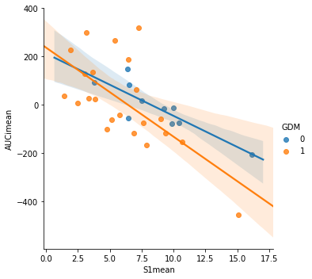

```python
model = smf.ols('AUCimean ~ S1mean', data=df).fit()
#print(model.summary())
aov_table = sm.stats.anova_lm(model, typ=2)
print(anova_table(aov_table))
sns.lmplot(x='S1mean', y='AUCimean', data=df, hue='GDM')
```

### Effect of sampling latency

```python
# Sampling latency
model = smf.ols('AUCgmean ~ sample_latency_mean_mins', data=df).fit()
#print(model.summary())
aov_table = sm.stats.anova_lm(model, typ=2)
print(anova_table(aov_table))
```

```
                                 sum_sq    df       mean_sq         F  \
sample_latency_mean_mins    5728.304733   1.0   5728.304733  0.160328
Residual                  607387.285654  17.0  35728.663862       NaN

                            PR(>F)    eta_sq  omega_sq
sample_latency_mean_mins  0.693842  0.009343 -0.046237
Residual                       NaN       NaN       NaN
```

```python
# Sampling latency
model = smf.ols('AUCimean ~ sample_latency_mean_mins', data=df).fit()
#print(model.summary())
aov_table = sm.stats.anova_lm(model, typ=2)
print(anova_table(aov_table))
```

```
                                 sum_sq    df       mean_sq         F  \
sample_latency_mean_mins    1188.403691   1.0   1188.403691  0.059162
Residual                  341484.751258  17.0  20087.338309       NaN

                            PR(>F)    eta_sq  omega_sq
sample_latency_mean_mins  0.810736  0.003468 -0.052098
Residual                       NaN       NaN       NaN
```

### Difference from baseline

```python
samples = ['S2mean','S3mean','S4mean']
for s in samples:
    print(stats.ttest_rel(df['S1mean'], df['{}'.format(s)]))
```

```
Ttest_relResult(statistic=-3.8007236551469226, pvalue=0.0006335539550446315)
Ttest_relResult(statistic=-5.384080173617944, pvalue=7.138616851783919e-06)
Ttest_relResult(statistic=-3.399751510609136, pvalue=0.0018724461895478228)
```